# Rmd for variant analysis from a VCF file: WES in a patient with renal ciliopathy syndrome

Lídia Romero Cortadellas

Course 2023-2024

# 1 Lectura de les dades

We read the vcf file from the readVcf function of the Bioconductor VariantAnnotation package. We will save the data corresponding to a specific chromosome to ease the processing of the information.

```r
> vcf <- readVcf("M46.snps.vcf", "hg19")
> vcf_chr <- vcf[grepl(names(vcf), pattern = "chr16:")]
```

Variant information is recorded in a VRange object. This is a regularly used GRanges object form that is part of Bioconductor. Includes chromosome, start position, end position, reference allele, and alternate allele. From the rowRanges function we extract the information.

```r
> rd_chr <- rowRanges(vcf_chr)
> head(rd_chr)
```

```
GRanges object with 6 ranges and 5 metadata columns:
                  seqnames    ranges strand | paramRangeID            REF
                     <Rle> <IRanges>  <Rle> |     <factor> <DNAStringSet>
  chr16:61590_C/G    chr16     61590      * |           NA              C
  chr16:61602_T/C    chr16     61602      * |           NA              T
  chr16:66484_G/A    chr16     66484      * |           NA              G
  chr16:66488_G/A    chr16     66488      * |           NA              G
  chr16:66506_G/A    chr16     66506      * |           NA              G
  chr16:66632_A/C    chr16     66632      * |           NA              A
                                 ALT      QUAL       FILTER
                  <DNAStringSetList> <numeric>  <character>
  chr16:61590_C/G                  G    265.77 LowCovFilter
  chr16:61602_T/C                  C    329.77         PASS
  chr16:66484_G/A                  A     34.77 LowCovFilter
  chr16:66488_G/A                  A    117.77 LowCovFilter
  chr16:66506_G/A                  A     34.77 LowCovFilter
  chr16:66632_A/C                  C     24.78 LowCovFilter
  -------
  seqinfo: 25 sequences from hg19 genome
```

# 2 Anotació de variants

For variant annotation we first retrieve information about SNPs from the dbSNP database and cross them with the variants in our file. We must take into account that the seqlevels, seqlevelStyle and genome of the two do not match and therefore we will have to combine them. The data we work with have the variants referenced to the genome version GrCh37.

```r
> all_snps <- SNPlocs.Hsapiens.dbSNP144.GRCh37
> tar_chr <- as.vector(seqnames(rd_chr)@values)
> tar_chr <- gsub("chr", "", tar_chr)
> tar_chr[grepl(tar_chr, pattern = "M")] <- "MT"
> tar_chr_keep <- c("1","2","3","4","5","6","7","8","9","10","11","12","13","14","15","16","17","18","19","20","21","22","X","Y","MT")
> condition <- tar_chr %in% tar_chr_keep
> tar_chr <- tar_chr[condition]
> my_snps <- snpsBySeqname(all_snps, c(tar_chr))
> my_snps[1:2]
```

```
UnstitchedGPos object with 2 positions and 2 metadata columns:
      seqnames       pos strand |   RefSNP_id alleles_as_ambig
         <Rle> <integer>  <Rle> | <character>      <character>
  [1]       16     60008      * | rs374973230                W
  [2]       16     60025      * | rs570662968                Y
  -------
  seqinfo: 25 sequences (1 circular) from GRCh37.p13 genome
```

```r
> seqlevelsStyle(my_snps) <- "UCSC"
> genome(my_snps) <- "hg19"
```

We extract information about SNPs to generate a reference data frame containing their position and ID. Next, we format our variant information into a data frame with the fields of interest. To do this we will have to break the chains of the variant. Once we have the two data frames, we can combine them to join our observed variants with their reference IDs.

```r
> snp_ID <- data.frame(posIDX = paste0(seqnames(my_snps), ":", pos(my_snps)), rsID = my_snps$RefSNP_id,stringsAsFactors = FALSE)
> head(snp_ID)
```

```
       posIDX        rsID
1 chr16:60008 rs374973230
2 chr16:60025 rs570662968
3 chr16:60031 rs538188167
4 chr16:60042 rs556164055
5 chr16:60045 rs367620903
6 chr16:60054  rs62028702
```

```r
> matV1 <- data.frame(Variant = names(rd_chr), stringsAsFactors = FALSE)
> matV1$chromosome <- gsub("(.*):(.*)_(.*)/(.*)", "\\1", matV1$Variant)
> matV1$start <- gsub("(.*):(.*)_(.*)/(.*)", "\\2", matV1$Variant)
> matV1$end <- gsub("(.*):(.*)_(.*)/(.*)", "\\2", matV1$Variant)
> matV1$ref_allele <- gsub("(.*):(.*)_(.*)/(.*)", "\\3", matV1$Variant)
> matV1$alt_allele <- gsub("(.*):(.*)_(.*)/(.*)", "\\4", matV1$Variant)
> matV1$posIDX <- gsub("(.*)_(.*)", "\\1", matV1$Variant)
> matV1[1:2, ]
```

```
          Variant chromosome start   end ref_allele alt_allele      posIDX
1 chr16:61590_C/G      chr16 61590 61590          C          G chr16:61590
2 chr16:61602_T/C      chr16 61602 61602          T          C chr16:61602
```

```r
> matS <- merge(matV1,snp_ID,all.x=TRUE,by="posIDX")
> matS <- dplyr::select(matS,-posIDX)
```

Based on the TxDb database, we relate the variants with the corresponding amino acid change. For this we execute the predictcoding() function providing our VCF object. It will use the ranges contained in it to search within a TxDb object. With this object we also identify in which position the variants are: 5’UTR, promoter, introns, exons, 3’ UTR or intergenes.

```r
> txdb <- TxDb.Hsapiens.UCSC.hg19.knownGene
> all <- locateVariants(vcf_chr, txdb, AllVariants())
> variants_vcf_chr <- ranges(all)
> location_variants <- mcols(all)$LOCATION
> variant_location_info <- data.frame(
+   Variant_Ranges = variants_vcf_chr,
+   Location_Info = location_variants)
> variant_location_info <- unique(variant_location_info)
> coding <- predictCoding(vcf_chr, txdb, seqSource = Hsapiens)
> head(coding, 10)
```

```
GRanges object with 10 ranges and 17 metadata columns:
                    seqnames    ranges strand | paramRangeID            REF
                       <Rle> <IRanges>  <Rle> |     <factor> <DNAStringSet>
    chr16:66632_A/C    chr16     66632      - |           NA              A
    chr16:66646_G/A    chr16     66646      - |           NA              G
   chr16:278950_C/T    chr16    278950      - |           NA              C
   chr16:679854_T/C    chr16    679854      + |           NA              T
  chr16:1291623_C/T    chr16   1291623      + |           NA              C
  chr16:1291623_C/T    chr16   1291623      + |           NA              C
  chr16:1291624_C/G    chr16   1291624      + |           NA              C
  chr16:1291624_C/G    chr16   1291624      + |           NA              C
  chr16:1307050_C/T    chr16   1307050      + |           NA              C
  chr16:1307050_C/T    chr16   1307050      + |           NA              C
                                   ALT      QUAL       FILTER      varAllele
                    <DNAStringSetList> <numeric>  <character> <DNAStringSet>
    chr16:66632_A/C                  C     24.78 LowCovFilter              G
    chr16:66646_G/A                  A    115.77 LowCovFilter              T
   chr16:278950_C/T                  T   2014.77         PASS              A
   chr16:679854_T/C                  C   1815.77         PASS              C
  chr16:1291623_C/T                  T    169.77     QDFilter              T
  chr16:1291623_C/T                  T    169.77     QDFilter              T
  chr16:1291624_C/G                  G    169.77     QDFilter              G
  chr16:1291624_C/G                  G    169.77     QDFilter              G
  chr16:1307050_C/T                  T    154.77     QDFilter              T
  chr16:1307050_C/T                  T    154.77     QDFilter              T
                       CDSLOC    PROTEINLOC   QUERYID        TXID         CDSID
                    <IRanges> <IntegerList> <integer> <character> <IntegerList>
    chr16:66632_A/C       827           276         6       58703        171300
    chr16:66646_G/A       813           271         7       58703        171300
   chr16:278950_C/T       103            35        12       58722        171357
   chr16:679854_T/C       356           119        14       56942        166070
  chr16:1291623_C/T       422           141        22       56995 166283,166284
  chr16:1291623_C/T       230            77        22       56996 166283,166284
  chr16:1291624_C/G       423           141        23       56995 166283,166284
  chr16:1291624_C/G       231            77        23       56996 166283,166284
  chr16:1307050_C/T       507           169        24       56997 166290,166291
  chr16:1307050_C/T       294            98        24       56998 166290,166291
                         GENEID   CONSEQUENCE       REFCODON       VARCODON
                    <character>      <factor> <DNAStringSet> <DNAStringSet>
    chr16:66632_A/C        <NA> nonsynonymous            ATT            AGT
```

[output cut: 8 more lines]

```
  chr16:1307050_C/T       23430 synonymous               GAC            GAT
                            REFAA         VARAA
                    <AAStringSet> <AAStringSet>
    chr16:66632_A/C             I             S
    chr16:66646_G/A             N             N
   chr16:278950_C/T             G             R
   chr16:679854_T/C             L             P
  chr16:1291623_C/T             T             I
  chr16:1291623_C/T             T             I
  chr16:1291624_C/G             T             T
  chr16:1291624_C/G             T             T
  chr16:1307050_C/T             D             D
  chr16:1307050_C/T             D             D
  -------
  seqinfo: 25 sequences from hg19 genome
```

```r
> matA <- data.frame(Variant=names(coding),
+                    chromosome=seqnames(coding),
+                    start=start(coding),end=end(coding),
+                    ref_allele=as.character(coding$REF),
+                    alt_allele=unlist(lapply(lapply(
+                    coding$ALT,`[[`,1),as.character)),
+                    GeneID=coding$GENEID,
+                    Protein_posi=unlist(lapply(lapply(
+                    coding$PROTEINLOC,`[[`,1),as.integer)),
+                    ref_AA=as.character(coding$REFAA),
+                    alt_AA=as.character(coding$VARAA),
+                    aaType = coding$CONSEQUENCE)
>
> for(i in 1:length(matA$aaType)){
+   if (matA$aaType[i] != "frameshift"){
+   matA$aaChange[i]<- paste0("p.",matA$ref_AA[i],matA$Protein_posi[i],matA$alt_AA[i])
+   }else{
+     matA$aaChange[i] <- NA
+ }
+ }
> head(matA)
```

```
            Variant chromosome   start     end ref_allele alt_allele GeneID
1   chr16:66632_A/C      chr16   66632   66632          A          C   <NA>
2   chr16:66646_G/A      chr16   66646   66646          G          A   <NA>
3  chr16:278950_C/T      chr16  278950  278950          C          T   <NA>
4  chr16:679854_T/C      chr16  679854  679854          T          C   <NA>
5 chr16:1291623_C/T      chr16 1291623 1291623          C          T   7177
6 chr16:1291623_C/T      chr16 1291623 1291623          C          T   7177
  Protein_posi ref_AA alt_AA        aaType aaChange
1          276      I      S nonsynonymous  p.I276S
2          271      N      N    synonymous  p.N271N
3           35      G      R nonsynonymous   p.G35R
4          119      L      P nonsynonymous  p.L119P
5          141      T      I nonsynonymous  p.T141I
6           77      T      I nonsynonymous   p.T77I
```

```r
> matA <- matA %>% distinct(Variant, .keep_all = TRUE)
```

We integrate data from SNPs (rs) and amino acid changes into the matS data frame.

```r
> matS$GeneID <- matA$GeneID[match(matS$Variant, matA$Variant)]
> matS$Protein_posi <- matA$Protein_posi[match(matS$Variant, matA$Variant)]
> matS$ref_AA <- matA$ref_AA[match(matS$Variant, matA$Variant)]
> matS$alt_AA <- matA$alt_AA[match(matS$Variant, matA$Variant)]
> matS$aaType <- matA$aaType[match(matS$Variant, matA$Variant)]
> matS$aaChange <- matA$aaChange[match(matS$Variant, matA$Variant)]
> matS$SampleID <- rownames(colData(vcf_chr))[1]
> matS$VariantLoc <- variant_location_info$Location_Info[match(matS$Variant, variant_location_info$Variant_Ranges.names)]
```

```r
> entrez_ids <- matS$GeneID
> gene_symbols <- AnnotationDbi::select(org.Hs.eg.db,keys=entrez_ids, columns="SYMBOL", keytype="ENTREZID")
> matS$Gene <- gene_symbols$SYMBOL[match(matS$GeneID, gene_symbols$ENTREZID)]
>
> omim_symbol <- AnnotationDbi::select(org.Hs.eg.db,keys=entrez_ids, columns="OMIM", keytype="ENTREZID")
> matS$OMIM <- omim_symbol$OMIM[match(matS$GeneID, omim_symbol$ENTREZID)]
>
> GO_symbols <- AnnotationDbi::select(org.Hs.eg.db,keys=entrez_ids, columns="GO", keytype="ENTREZID")
> matS$GO <- GO_symbols$GO[match(matS$GeneID, omim_symbol$ENTREZID)]
>
> pp <- AnnotationDbi::select(PolyPhen.Hsapiens.dbSNP131, keys=matS$rsID,
+           cols=c("TRAININGSET", "PREDICTION", "PPH2PROB"))
> head(pp[!is.na(pp$PREDICTION), ])
```

```
data frame with 0 columns and 0 rows
```

```r
> matS$polyphenpredict <- pp$PREDICTION[match(matS$rsID, pp$RSID)]
>
> ensembl_gene <- AnnotationDbi::select(org.Hs.eg.db,keys=entrez_ids, columns="ENSEMBL", keytype="ENTREZID")
> matS$ENSEMBL <- ensembl_gene$ENSEMBL[match(matS$GeneID, ensembl_gene$ENTREZID)]
>
> GO_ID <- matS$GO
> GO_term<- AnnotationDbi::select(GO.db,keys=GO_ID, columns="TERM", keytype="GOID")
> matS$GOterm <- GO_term$TERM[match(matS$GO, GO_term$GOID)]
>
> GO_onto <- GO_term<- AnnotationDbi::select(GO.db,keys=GO_ID, columns="ONTOLOGY", keytype="GOID")
> matS$GOOntology <- GO_onto$ONTOLOGY[match(matS$GO, GO_term$GOID)]
>
> genotypes <- geno(vcf_chr)
> genotype_data <- data.frame(genotypes$GT)
> sample_name <- names(genotype_data[1])
> matS$genotype <- genotype_data[[sample_name]][match(matS$Variant, rownames(genotype_data))]
> allelic_depth <- data.frame(genotypes$AD)
> allelic_depth <- allelic_depth[1]
> col_name <- paste("Reads", sample_name, sep = "")
> allelic_depth[[col_name]] <- format(allelic_depth[[sample_name]], big.mark = ",")
> split_allelic <- separate(allelic_depth, col_name, into = c("ReadsRef", "ReadsAlt"), sep = ",")
> matS$ReadsRef <- split_allelic$ReadsRef[match(matS$Variant, rownames(split_allelic))]
> matS$ReadsAlt <- split_allelic$ReadsAlt[match(matS$Variant, rownames(split_allelic))]
>
> gene_ids <- matS$ENSEMBL
> ensembl <- useEnsembl(biomart = "ensembl", dataset = "hsapiens_gene_ensembl")
> omim_description <- getBM(
+   attributes = c("ensembl_gene_id", "mim_morbid_description"),
+   filters = "ensembl_gene_id",
+   values = gene_ids,
+   mart = ensembl
+ )
>
> omim_description_combined <- omim_description %>% group_by(ensembl_gene_id) %>% summarize(mim_morbid_description = paste(mim_morbid_description, collapse = "/ "))
> matS$DiseaseOMIM <- omim_description_combined$mim_morbid_description[match(matS$ENSEMBL, omim_description_combined$ensembl_gene_id)]
>
> getType <- function(ref, alt){
+   if(nchar(ref) == nchar(alt)){
+     if(nchar(ref) == 1){
+       return("SNP")
+     } else {
+       return("Complex variant")
+     }
+   } else if (nchar(ref) > nchar(alt)) {
+     return("Deletion")
+   } else {
+     return("Insertion")
+   }
+ }
> matS$Type <- mapply(getType, matS$ref_allele, matS$alt_allele)
>
> freq_data <- useMart("ENSEMBL_MART_SNP", dataset="hsapiens_snp")
> minorallfreq <- getBM(attributes = c("refsnp_id", "minor_allele", "minor_allele_freq"), filters = "snp_filter", values = matS$rsID, mart = freq_data)
> matS$MAF <- minorallfreq$minor_allele_freq[match(matS$rsID,minorallfreq$refsnp_id)]
```

Optionally and according to the graphic representation you want to make, the data will have to be converted into other formats to be able to use the functions that generate these graphics. In this case, the annotated data has been converted to maf format to make some of the plots For this, the names of the columns of the data frame must be modified and in some cases also their content. For example, instead of chr9, we will have to change it to “9”.

```r
> matS_maf <- matS[,c ("Gene", "chromosome", "start", "end","ref_allele", "alt_allele", "aaType", "Type", "SampleID")]
> colnames(matS_maf) <- c('Hugo_Symbol', 'Chromosome', 'Start_Position', 'End_Position', 'Reference_Allele', 'Tumor_Seq_Allele2', 'Variant_Classification', 'Variant_Type', 'Tumor_Sample_Barcode')
> matS_maf$Chromosome <- sub("^chr", "", matS_maf$Chromosome)
> matS_maf$Start_Position <- as.integer(matS_maf$Start_Position)
> matS_maf$End_Position <- as.integer(matS_maf$End_Position)
> matS_maf$Variant_Type <- ifelse(matS_maf$Variant_Type == "Deletion", "DEL",
+                                 ifelse(matS_maf$Variant_Type == "Insertion", "INS", matS_maf$Variant_Type))
> matS_maf$Variant_Classification <- as.character(matS_maf$Variant_Classification)
>
> get_mutation_type <- function(ref, alt, var_type, var_class) {
+   if (is.na(var_class)) {
+     return("Missing_Classification") # Handle missing values in Variant_Classification
+   } else if (var_type == "DEL" && var_class == "frameshift") {
+     return("Frame_Shift_Del") # Frameshift deletion
+   } else if (var_type == "INS" && var_class == "frameshift") {
+     return("Frame_Shift_Ins") # Frameshift insertion
+   } else if (var_class == "nonsynonymous") {
+     if (is.na(ref) || is.na(alt)) {
+       return("Missing_Allele") # Handle missing values in Allele columns
+     } else if (nchar(ref) != nchar(alt)) {
+       if (nchar(ref) > nchar(alt)) {
+         return("In_Frame_Del") # In-frame deletion
+       } else {
+         return("In_Frame_Ins") # In-frame insertion
+       }
+     } else if (var_type == "SNP") {
+       return("Missense_Mutation") # SNP classified as Missense Mutation
+     }
+   } else if (var_class == "synonymous") {
+     return("Silent") # Synonymous mutations as Silent
+   } else if (var_class == "nonsense") {
+     return("Nonsense_Mutation") # Nonsense mutations
+   }
+   return("Other") # Other cases or unchanged rows
+ }
> matS_maf$Mutation_type <- mapply(get_mutation_type, matS_maf$Reference_Allele, matS_maf$Tumor_Seq_Allele2, matS_maf$Variant_Type, matS_maf$Variant_Classification)
> matS_maf <- subset(matS_maf, select = -Variant_Classification)
> names(matS_maf)[names(matS_maf) == "Mutation_type"] <- "Variant_Classification"
> matS_maf$AAChange <- matS$aaChange[match(matS_maf$Hugo_Symbol, matS$Gene)]
> maf_object <- read.maf(maf = matS_maf)
```

```
-Validating
--Removed 2 duplicated variants
--Found  271  variants with no Gene Symbols
--Annotating them as 'Unknown' for convenience
--Non MAF specific values in Variant_Classification column:
  Missing_Classification
-Silent variants: 284
-Summarizing
-Processing clinical data
--Missing clinical data
-Finished in 0.050s elapsed (0.010s cpu)
```

```r
> matS <- matS[, -which(names(matS) == "aaType")]
> matS$Variant_Classification <- matS_maf$Variant_Classification
> head(matS)
```

```
             Variant chromosome    start      end ref_allele alt_allele
1 chr16:10273739_A/C      chr16 10273739 10273739          A          C
2 chr16:10273745_A/C      chr16 10273745 10273745          A          C
3 chr16:10273751_A/C      chr16 10273751 10273751          A          C
4 chr16:10273753_T/C      chr16 10273753 10273753          T          C
5 chr16:10567770_A/T      chr16 10567770 10567770          A          T
6 chr16:10855537_A/T      chr16 10855537 10855537          A          T
         rsID GeneID Protein_posi ref_AA alt_AA aaChange SampleID VariantLoc
1 rs747551467   <NA>           NA   <NA>   <NA>     <NA>      M46     intron
2 rs777248627   <NA>           NA   <NA>   <NA>     <NA>      M46     intron
3 rs771263022   <NA>           NA   <NA>   <NA>     <NA>      M46     intron
4        <NA>   <NA>           NA   <NA>   <NA>     <NA>      M46     intron
5 rs777857986   <NA>           NA   <NA>   <NA>     <NA>      M46     intron
6        <NA>   <NA>           NA   <NA>   <NA>     <NA>      M46     intron
  Gene OMIM   GO ENSEMBL GOterm GOOntology genotype ReadsRef ReadsAlt
1 <NA> <NA> <NA>    <NA>   <NA>       <NA>      0/1       14        5
2 <NA> <NA> <NA>    <NA>   <NA>       <NA>      0/1       11        8
3 <NA> <NA> <NA>    <NA>   <NA>       <NA>      0/1       14        1
4 <NA> <NA> <NA>    <NA>   <NA>       <NA>      0/1       14        1
5 <NA> <NA> <NA>    <NA>   <NA>       <NA>      0/1       20        0
6 <NA> <NA> <NA>    <NA>   <NA>       <NA>      0/1       56        4
  DiseaseOMIM Type MAF Variant_Classification
1        <NA>  SNP  NA Missing_Classification
2        <NA>  SNP  NA Missing_Classification
3        <NA>  SNP  NA Missing_Classification
4        <NA>  SNP  NA Missing_Classification
5        <NA>  SNP  NA Missing_Classification
6        <NA>  SNP  NA Missing_Classification
```

# 3 Visualització de resultats

We first observe the distribution of variants according to various characteristics.

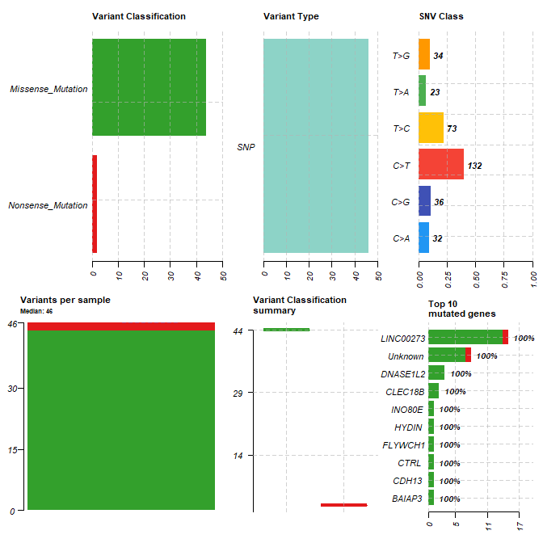

Figura 1. Overview general del dataset WES.

```r
> plotmafSummary(maf = maf_object, rmOutlier = TRUE, addStat = 'median', dashboard = TRUE, titvRaw = FALSE)
```

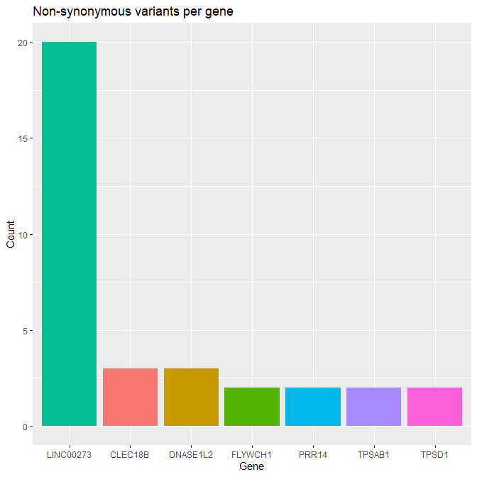

Figura 2. Nombre de variants per gen.

```r
> gene_counts <- matS %>%
+   filter(!is.na(Gene), VariantLoc != "Silent") %>%
+   group_by(Gene) %>%
+   summarise(Frequency = n()) %>%
+   filter(Frequency > 1)
>
> ggplot(gene_counts, aes(x = reorder(Gene, - Frequency ),y = Frequency, fill = Gene )) +
+   geom_bar(stat = "identity") +
+   labs(title = "Non-synonymous variants per gene", x = "Gene", y = "Count") +
+   theme(legend.position = "none")
```

```r
> gene_counts$GO <- matS$GOterm[match(gene_counts$Gene, matS$Gene)]
> gene_counts$disease <- matS$DiseaseOMIM[match(gene_counts$Gene, matS$Gene)]
> gene_counts[order(desc(gene_counts$Frequency)), ]
```

```
# A tibble: 7 × 4
  Gene      Frequency GO                                  disease
  <chr>         <int> <chr>                               <chr>
1 LINC00273        20 protein methylation                 ""
2 CLEC18B           3 proteolysis                         ""
3 DNASE1L2          3 translation release factor activity ""
4 FLYWCH1           2 GTPase activity                     ""
5 PRR14             2 cytoplasm                           ""
6 TPSAB1            2 DNA binding                         ""
7 TPSD1             2 nucleus                             ""
```

And of all the variants identified, where are they located within the DNA/mRNA?

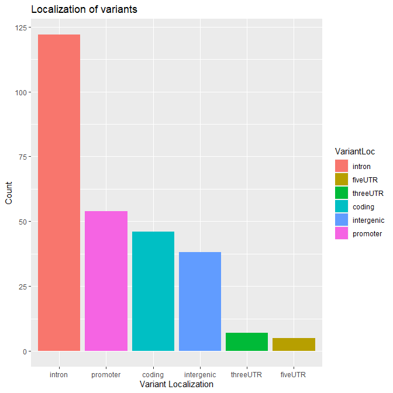

```r
> loc_filtered <- matS %>%
+   filter(!is.na(VariantLoc)) %>%
+   group_by(VariantLoc) %>%
+   summarise(Frequency = n())
>
>
> ggplot(loc_filtered, aes(x=reorder(VariantLoc, - Frequency), y=Frequency, fill = VariantLoc)) +
+   geom_bar(stat = "identity") +
+   labs(title = "Localization of variants", x = "Variant Localization", y = "Count")
```

We see how the variants are distributed along chromosome 16.

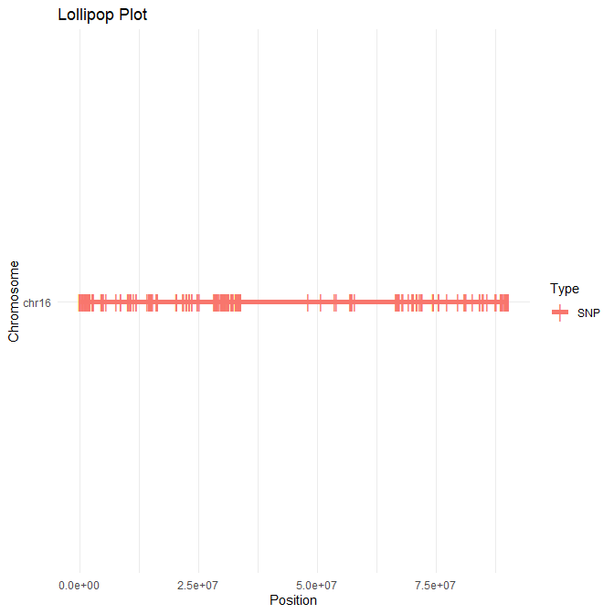

Figura 3. Variants al llarg del cromosoma 16.

```r
> matS$start <- as.integer(matS$start)
> matS$end <- as.integer(matS$end)
> ggplot(matS, aes(x=chromosome, y=start, color=Type)) +
+   geom_segment(aes(xend=chromosome, yend = start, y = 0), size = 2) +
+   geom_point(size = 5, shape = "|") +
+   labs(title = "Lollipop Plot", x = "Chromosome", y ="Position") +
+   theme_minimal() +
+   coord_flip()
```